# Multivariate Data Analysis - chapter 04

# 4.군집분석

## 3. 계층적 군집분석

- 계층적 군집분석에서 관찰치의 군집화 과정은 각 관찰치들을 순차적으로 유사성의 순서를 이용하여 연결하는 과정으로 연결방법에는 다음과 같이 다섯 가지가 있음.
1. 최단연결법
2. 최장연결법
3. 중심연결법
4. 평균연결법
5. 와드의 방법(Ward’s method)

   연결가능한 군집조합 중 연결된 후에 군집 내 제곱합을 계산하여 최소 제곱합을 가지게되는 군집끼리 연결 시키는 방법
- 덴드로그램(dendrogram): 계층적 군집분석 과정에서 관찰치들의 연결결과를 순서에 따라 정리해 놓은 그림을 말함
  - 이 덴드로그램에 의하여 계층적 군집분석방법의 결과를 이해할 수 있음.
  - 덴드로그램은 각 관찰치를 연결하는 가지들로 구성되어 있으며 관찰치들이 각 군집에 배정되는 순서를 볼 수 있도록 함.
  - 가지의 길이는 관찰치와 군집이 통합될 때의 거리측도 혹은 유사성측도와 비례

#### 고려사항

##### (1) 방법의 선택

- 각 군집분석방법의 특징
  - 최단연결법: 하나의 큰 군집화를 순차적으로 만들어가는 경향
  - 최장연결법: 비슷한 크기로 여러 개 군집을 만들어서 서로 연결시키는 경향
- 최단연결법은 최장연결법보다 더 적은 수의 군집을 찾게 됨. 반면 최장연결법은 군집의 개수는 많으나 한 군집 내의 크기가 더 작은 결과를 보임  
  대부분의 기타 방법들은 최단연결법의 특성과 최장연결법의 특징의 중간에 놓여 있다고 볼 수 있음.
- 여러 가지 계층적 군집분석방법 중에서 어느것이 더 유용하다고 말하기는 어렵고, 여러 군집방법을 수행해 보고 비교하는 것도 좋은 접근방법임.

##### (2) 군집분석 결과의 검증

- 계층적 군집분석방법에 의해서 군집을 구한 후, 결과의 타당성을 검증해 보는 것은 매우 중요한 습관임.
- 군집결과의 검증을 위해서는 묶인 군집들이 상식적으로 타당한 군집인지 다변량 그림 등을 그려서 확인할 수 있음.
  - 다변량그림의 예: ① 변수가 2개인 경우에 산점도, ② 주성분분석에서 구해진 상위 2개의 주성분을 이용한 산점도, ③ 변수가 3개인 경우에 3-차원 산점도 혹은 bubble 그림, ④ 주성분분석에서 구해진 상위 3개주성분을 이용한 3-차원 산점도 및 bubble 그림, ⑤ star 그림과 같은 다변량 그림(Andrews 그림과 Chernoff 얼굴그림도 가능) 등.

##### (3) 군집의 수 결정

- 계층적 군집분석에서 군집의 수를 결정하는 문제는 대부분 덴드로그램을 활용하는 방법을 사용. 덴드로그램에서 거리측도의 값이 큰 변화를 보이는 위치에서 군집의 수를 결정하는 방법임.

### 4. 비계층적 군집분석

- 계층적 군집분석방법 : 기본적으로 각 관찰치 사이의 유사성/거리 행렬을 구한 후에 관찰치들을 가까운 순서대로 연결해 나가는 방법임. 이 방법은 관찰치의 수가 많은 경우에는 관찰치들 사이의 유사성/거리 행렬을 구하는 것이 매우 방대하고, 오랜 시간이 소요됨.
- 관찰치의 수가 많은 경우 효율적인 방법이 비계층적 군집분석방법인 K-평균 군집분석
- K-평균 군집분석 : 군집의 수를 미리 K개로 정한 후에 관찰치들을 K개의 군집으로 나누는 방법
- K-평균 군집분석 절차
  1. 군집의 수 K를 정함
  2. 임의의 K개 관찰치를 K개 각 군집에 임의로 지정. 이를 K개 각 군집의 중심으로 이용
  3. 모든 관찰치를 군집중심으로부터 유클리디안 거리가 최소인 군집에 귀속
  4. 각 군집에 속한 관찰치들을 이용하여 군집중심을 새로 계산
  5. 변화(군집 간 관찰치 이동)가 없을 때까지 단계 3과 4를 반복

#### 고려사항

##### (1) 초깃값의 설정

- K-평균 군집분석방법의 문제점은 군집화의 결과가 초깃값의 설정에 의존한다는 점임.
- 초깃값을 설정하는 대표적 방법은 데이터 내 임의의 K개 관찰치를 각 군집의 초깃값으로 설정하는 것임.
- 요즈음 많이 사용되는 방법은 계층적 군집분석을 만저 수행하여 구해진, 특히 와드( Ward)의 방법을 사용하여 계층적 군집분석을 수행한 후 중심점을 초깃값으로 사용한다면 매우 좋은 결과를 보인다고 알려져 있음.
- 데이터가 대용량이어서 계층적 군집분석을 사용해 초깃값을 구하기 어려운 경우에는 원 데이터로부터 적은 표본을 추출하여 계층적 군집분석을 수행한 후 초깃값을 구하기도 함.

##### (2) 군집의 수 결정

- K-평균 군집분석에서 군집의 수를 결정하는 문제는 계층적 군집분석과 마찬가지로 정도는 없음.
- 먼저 2개의 군집에 대한 K-평균 군집분석을 수행하고, 그 다음으로 3개 군집에 대하여, 그리고 4개의 군집에 대한 K-평균 군집분석 등과 같이 군집의 수를 증가시키면서 K-평균 군집분석을 반복하여 수행한 후 이러한 결과 중 가장 좋은 결과를 보이는 군집의 수를 결정하는 방법.
- 또 다른 방법으로, 군집의 수행 이전에 주성분분석을 먼저 수행하고 상위 2개의 주성분을 이용하여 군집의 개수를 미리 그림으로 확인해 보는 방법도 있음.
- 마지막으로 계층적 군집분석을 먼저 수행하여 군집의 수를 덴드로그램을 통하여 미리 정한 후 비계층적 군집분석을 수행하는 방법도 사용

##### (3) 실용적 고려사항

- K-평균 군집분석은 실무적으로 아주 활용도가 높은 군집분석방법임
  - 빠른 연산으로 인해 대규모의 데이터에도 손쉽게 군집분석 결과를 구할 수 있다는 장점이 있음.
- K-평균 군집분석방법의 검증은 비계층적 군집분석방법과 마창가지로 그래프를 활용한 검증방법이 가능

### R - 군집분석 사례

#### (1) 계층적군집분석 실행하기

```r
beer = read.csv("./data/beerbrand.csv", header = T, row.names = 1)
head(beer)
```

```
##               calories sodium alcohol cost
## BUDWEISER          144     15     4.7 0.43
## SCHLITZ            151     19     4.9 0.43
## LOWENBRAU          157     15     4.9 0.48
## KRONENBOURG        170      7     5.2 0.73
## HEINEKEN           152     11     5.0 0.77
## OLD MILWAUKEE      145     23     4.6 0.28
```

```r
summary(beer)
```

```
##     calories         sodium         alcohol          cost
##  Min.   : 68.0   Min.   : 6.00   Min.   :2.30   Min.   :0.2800
##  1st Qu.:110.2   1st Qu.: 9.50   1st Qu.:4.20   1st Qu.:0.4300
##  Median :144.0   Median :15.00   Median :4.65   Median :0.4400
##  Mean   :132.4   Mean   :14.95   Mean   :4.44   Mean   :0.4965
##  3rd Qu.:150.2   3rd Qu.:19.00   3rd Qu.:4.90   3rd Qu.:0.4850
##  Max.   :175.0   Max.   :27.00   Max.   :5.50   Max.   :0.7900
```

#### (2) 자료의 표준화

```r
zbeer = scale(beer)
round(apply(zbeer, 2, mean), 3)
```

```
## calories   sodium  alcohol     cost
##        0        0        0        0
```

```r
round(apply(zbeer, 2, sd), 3)
```

```
## calories   sodium  alcohol     cost
##        1        1        1        1
```

#### (3) 거리행렬 계산하기

```r
zbeer_euc = dist(zbeer)
zbeer_euc[1]
```

```
## [1] 0.7015818
```

```r
zbeer_man = dist(zbeer, "manhattan")
zbeer_man[1]
```

```
## [1] 1.102367
```

#### (4) 계층적 군집분석 실행하기 - 최단연결법

```r
hc_s = hclust(zbeer_euc, method = "single")
hc_s
```

```
##
## Call:
## hclust(d = zbeer_euc, method = "single")
##
## Cluster method   : single
## Distance         : euclidean
## Number of objects: 20
```

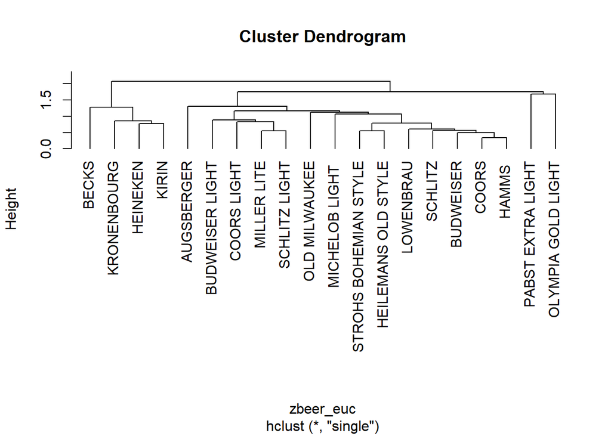

```r
plot(hc_s, hang=-1)
```

#### (5) 계층적 군집분석 실행하기 - 최장연결법

```r
hc_c = hclust(zbeer_euc, method = "complete")
hc_c
```

```
##
## Call:
## hclust(d = zbeer_euc, method = "complete")
##
## Cluster method   : complete
## Distance         : euclidean
## Number of objects: 20
```

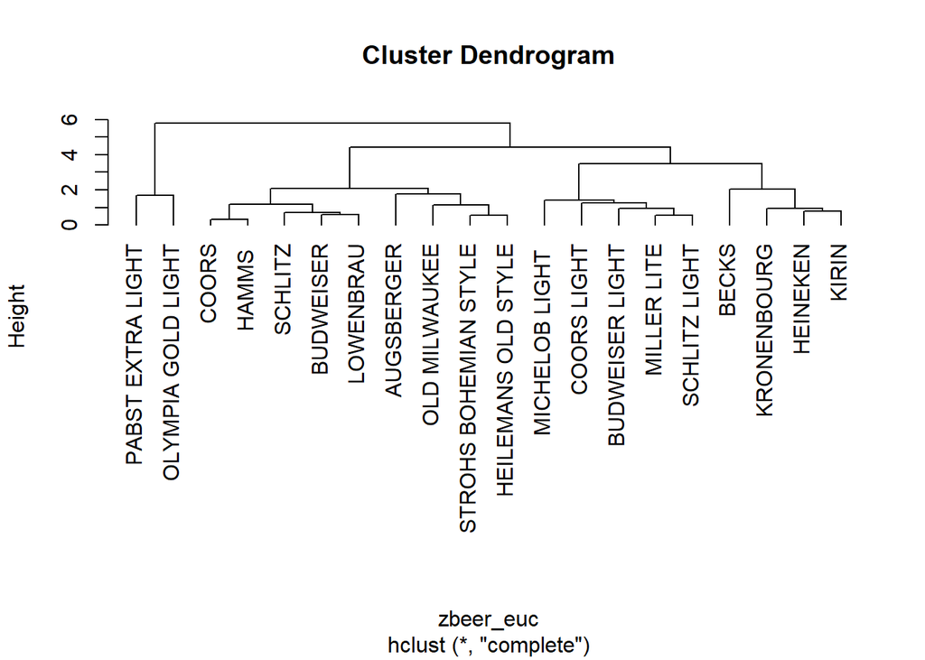

```r
plot(hc_c, hang = -1)
```

#### (6) 계층적 군집분석 실행하기 - 중심연결법

```r
hc_cen = hclust(zbeer_euc, method = "centroid")
hc_cen
```

```
##
## Call:
## hclust(d = zbeer_euc, method = "centroid")
##
## Cluster method   : centroid
## Distance         : euclidean
## Number of objects: 20
```

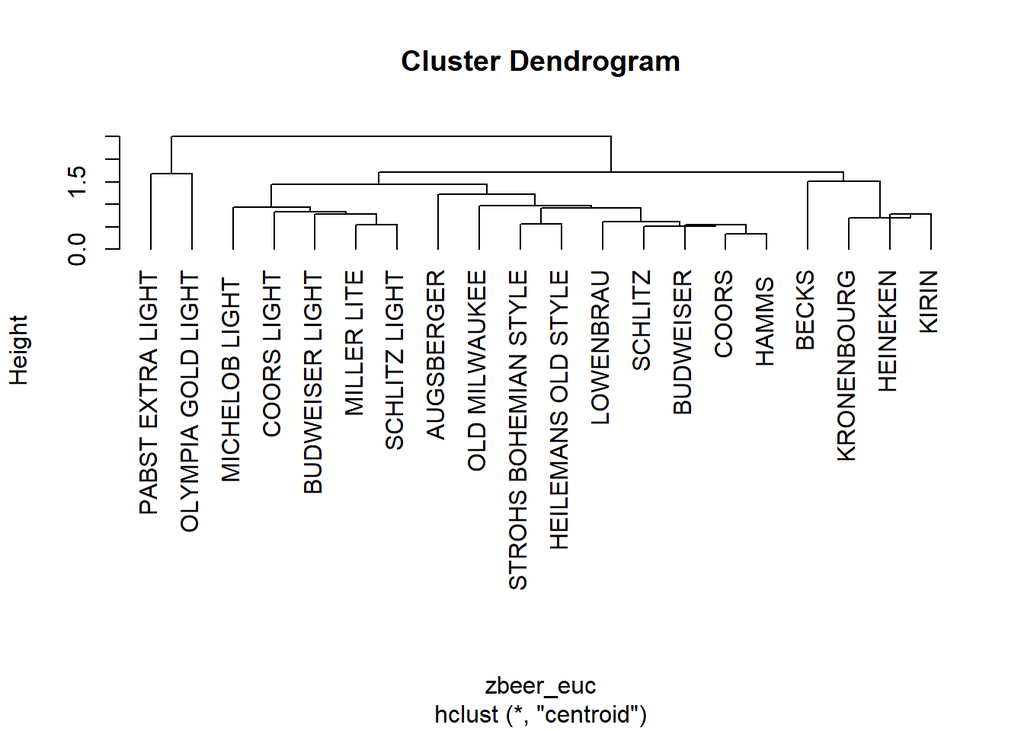

```r
plot(hc_cen, hang = -1)
```

#### (7) 계층적 군집분석 실행하기 - 와드의 방법

```r
hc_w = hclust(zbeer_euc, method = "ward.D")
hc_w
```

```
##
## Call:
## hclust(d = zbeer_euc, method = "ward.D")
##
## Cluster method   : ward.D
## Distance         : euclidean
## Number of objects: 20
```

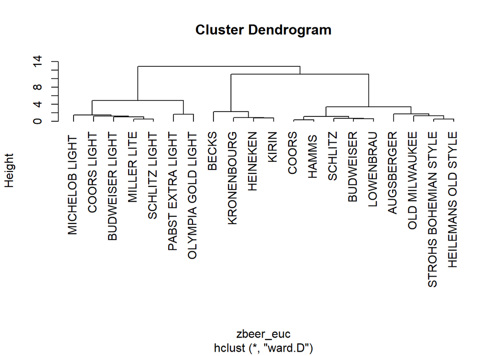

```r
plot(hc_w, hang = -1)
```

#### (8) 소속 군집 확인

```r
hc_cen24 = cutree(hc_cen, 2:4)
hc_cen24
```

```
##                       2 3 4
## BUDWEISER             1 1 1
## SCHLITZ               1 1 1
## LOWENBRAU             1 1 1
## KRONENBOURG           1 2 2
## HEINEKEN              1 2 2
## OLD MILWAUKEE         1 1 1
## AUGSBERGER            1 1 1
## STROHS BOHEMIAN STYLE 1 1 1
## MILLER LITE           1 1 1
## BUDWEISER LIGHT       1 1 1
## COORS                 1 1 1
## COORS LIGHT           1 1 1
## MICHELOB LIGHT        1 1 1
## BECKS                 1 2 2
## KIRIN                 1 2 2
## PABST EXTRA LIGHT     2 3 3
## HAMMS                 1 1 1
## HEILEMANS OLD STYLE   1 1 1
## OLYMPIA GOLD LIGHT    2 3 4
## SCHLITZ LIGHT         1 1 1
```

### R - K-평균 군집분석

#### (1) K-평균 군집분석 실행

```r
kmc = kmeans(zbeer, centers = 2)
kmc
```

```
## K-means clustering with 2 clusters of sizes 6, 14
##
## Cluster means:
##     calories     sodium    alcohol       cost
## 1 -1.3407148 -0.7268097 -1.1275218 -0.3930246
## 2  0.5745921  0.3114899  0.4832236  0.1684391
##
## Clustering vector:
##             BUDWEISER               SCHLITZ             LOWENBRAU
##                     2                     2                     2
##           KRONENBOURG              HEINEKEN         OLD MILWAUKEE
##                     2                     2                     2
##            AUGSBERGER STROHS BOHEMIAN STYLE           MILLER LITE
##                     2                     2                     1
##       BUDWEISER LIGHT                 COORS           COORS LIGHT
##                     1                     2                     1
##       MICHELOB LIGHT                  BECKS                 KIRIN
##                     2                     2                     2
##     PABST EXTRA LIGHT                HAMMS    HEILEMANS OLD STYLE
##                     1                     2                     2
##    OLYMPIA GOLD LIGHT         SCHLITZ LIGHT
##                     1                     1
##
## Within cluster sum of squares by cluster:
## [1]  9.515432 34.328491
##  (between_SS / total_SS =  42.3 %)
##
## Available components:
##
## [1] "cluster"      "centers"      "totss"        "withinss"     "tot.withinss"
## [6] "betweenss"    "size"         "iter"         "ifault"
```

#### (2) 소속 군집 산점도

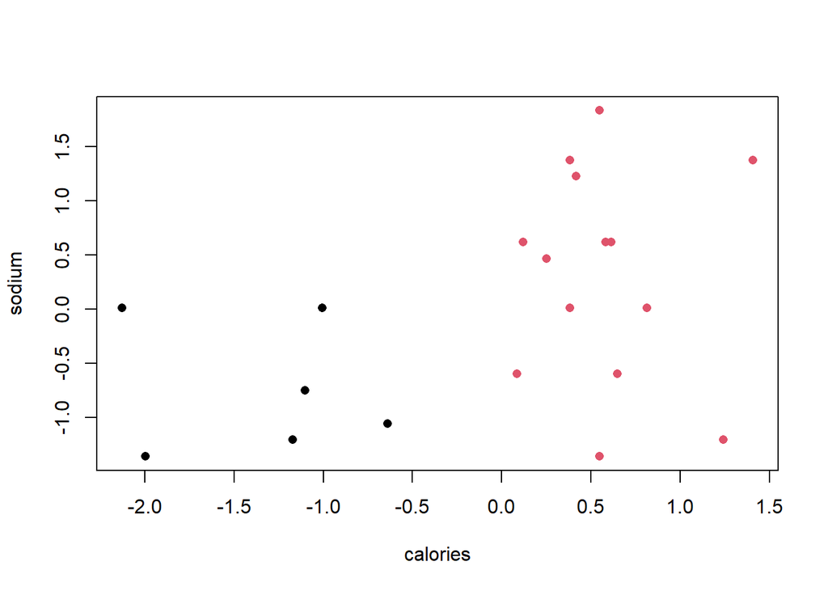

```r
plot(zbeer, col=kmc$cluster, pch=16)
```

- K-평균 군집 데이터의 모든 변수를 그리기위한 R 명령어

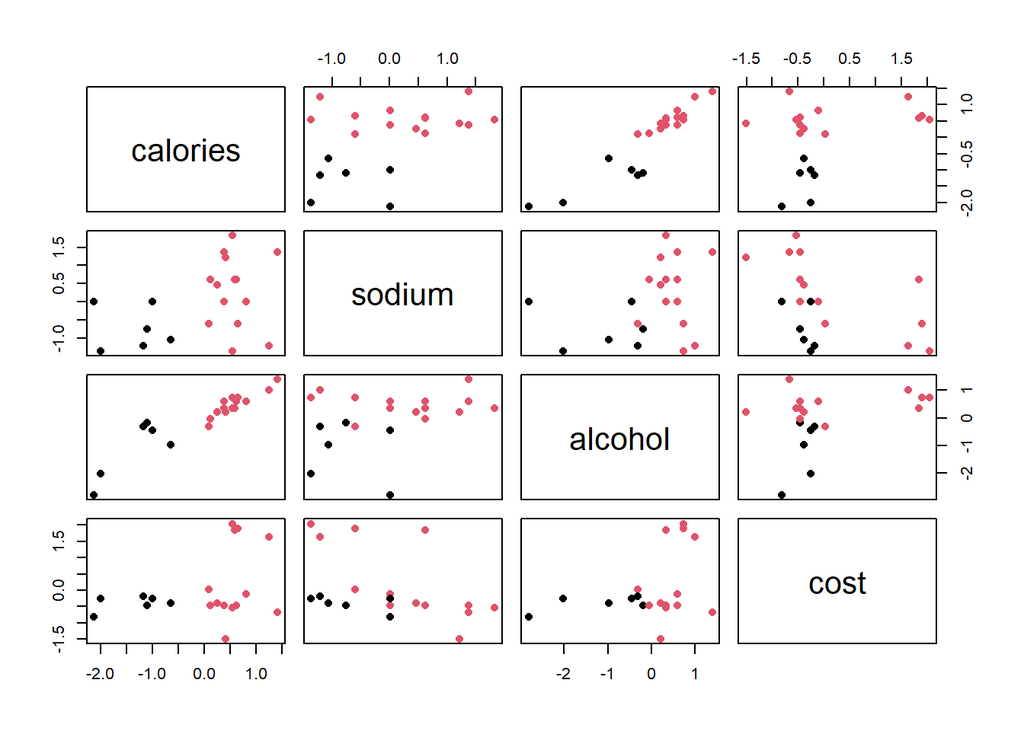

```r
pairs(zbeer, col=kmc$cluster, pch=16)
```

```r
# cex.labels = 1.5 사용하지 않는게 변수명이 더 크게 찍힌다.
```

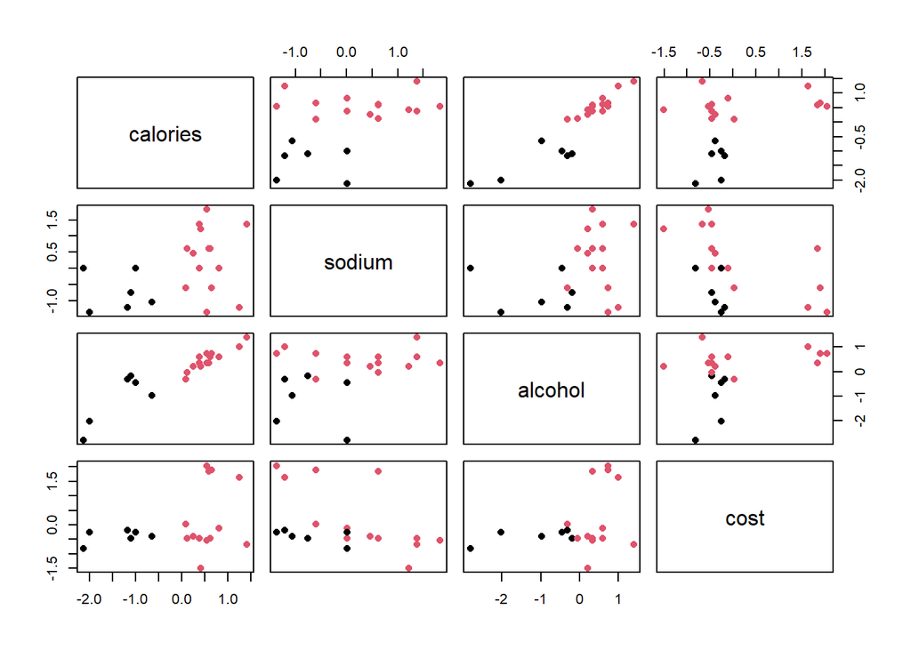

```r
pairs(zbeer, col=kmc$cluster, pch=16, cex.labels = 1.5)
```

### 파이썬 - 계층적 군집분석

#### (1) 데이터 파일 읽기

```python
import pandas as pd
import numpy as np
import matplotlib.pyplot as plt

beer = pd.read_csv("./data/beerbrand.csv", index_col="name")
beer.head()
```

```
##              calories  sodium  alcohol  cost
## name
## BUDWEISER         144      15      4.7  0.43
## SCHLITZ           151      19      4.9  0.43
## LOWENBRAU         157      15      4.9  0.48
## KRONENBOURG       170       7      5.2  0.73
## HEINEKEN          152      11      5.0  0.77
```

```python
beer.describe()

# 표준화 시행
```

```
##          calories     sodium    alcohol       cost
## count   20.000000  20.000000  20.000000  20.000000
## mean   132.400000  14.950000   4.440000   0.496500
## std     30.257491   6.581273   0.759778   0.143757
## min     68.000000   6.000000   2.300000   0.280000
## 25%    110.250000   9.500000   4.200000   0.430000
## 50%    144.000000  15.000000   4.650000   0.440000
## 75%    150.250000  19.000000   4.900000   0.485000
## max    175.000000  27.000000   5.500000   0.790000
```

```python
from sklearn.preprocessing import StandardScaler
zbeer = StandardScaler().fit_transform(beer)
```

#### (2) 계층적 군집분석 - 최단연결법

```python
import scipy.cluster.hierarchy as sch

slink = sch.linkage(zbeer, 'single')
plt.figure(figsize=(12,7))
sch.dendrogram(slink, leaf_rotation=45, leaf_font_size=8, labels=beer.index)
```

[output not shown]

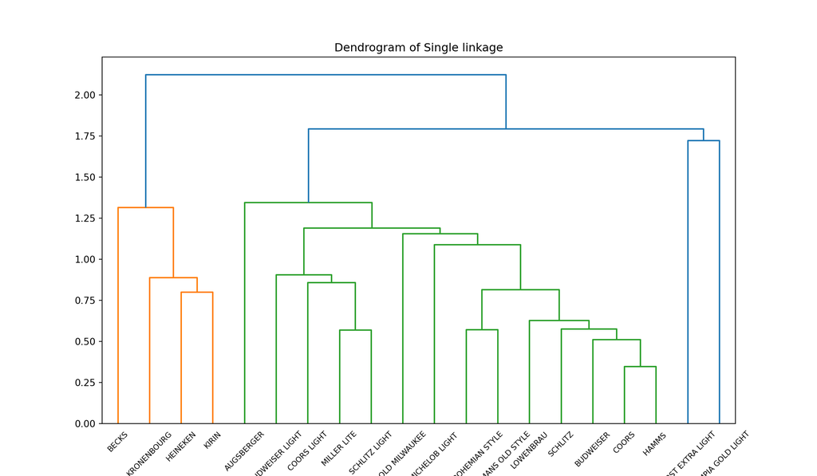

```python
plt.title("Dendrogram of Single linkage")
plt.show()
```

#### (3) 계층적 군집분석 - 와드연결법

```python
wlink = sch.linkage(zbeer, 'ward')
plt.figure().set_figwidth(12)
sch.dendrogram(wlink, leaf_rotation=45, leaf_font_size=8, labels=beer.index)
```

[output not shown]

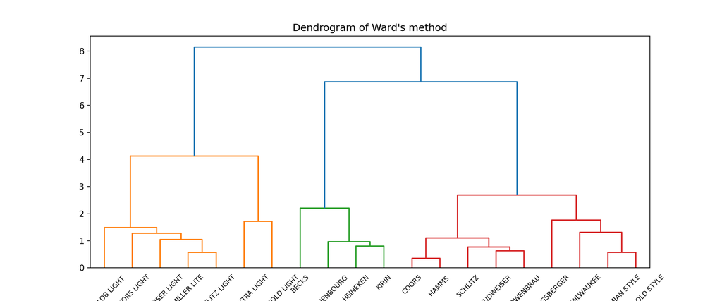

```python
plt.title("Dendrogram of Ward's method")
plt.show()
```

#### (4) 계층적 군집분석 - 중심연결법

```python
clink = sch.linkage(zbeer, 'centroid')
plt.figure(figsize=(12,7))
sch.dendrogram(clink, leaf_font_size = 8, leaf_rotation=45, labels=beer.index)
```

[output not shown]

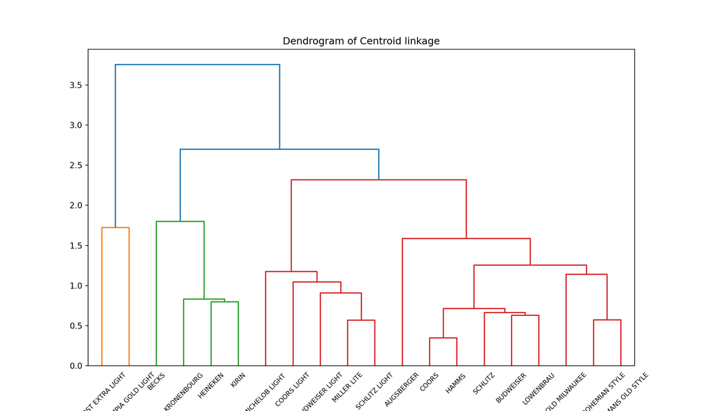

```python
plt.title("Dendrogram of Centroid linkage")
plt.show()
```

#### (5) 소속 군집 확인.

```python
from sklearn.cluster import AgglomerativeClustering

# 계층적군집방법 : ward 방법법
wcluster = AgglomerativeClustering(n_clusters=4, affinity='euclidean', linkage='ward')
member = wcluster.fit_predict(zbeer)
member

# 군집별 평균계산
```

```
## array([0, 0, 0, 2, 2, 0, 0, 0, 3, 3, 0, 3, 3, 2, 2, 1, 0, 0, 1, 3],
##       dtype=int64)
```

```python
member1 = pd.DataFrame(member, columns= ['cluster'], index=beer.index)
data_combinded = beer.join(member1)
data_combinded.groupby('cluster').mean()
```

```
##          calories     sodium  alcohol      cost
## cluster
## 0          149.00  20.444444    4.800  0.415556
## 1           70.00  10.500000    2.600  0.420000
## 2          155.25  10.750000    4.975  0.762500
## 3          109.20  10.200000    4.100  0.460000
```

#### (6) K-평균 군집분석

```python
from sklearn.cluster import KMeans
from sklearn.preprocessing import StandardScaler

# 표준화
zbeer = StandardScaler().fit_transform(beer)

#
kmc = KMeans(n_clusters=2)
kmc.fit(zbeer)
```

```
KMeans(n_clusters=2)
```

```python
kmc.cluster_centers_
```

```
## array([[ 0.56626765,  0.83403073,  0.47262786, -0.33186571],
##        [-0.56626765, -0.83403073, -0.47262786,  0.33186571]])
```

```python
kmc.labels_
```

```
## array([0, 0, 0, 1, 1, 0, 0, 0, 1, 1, 0, 1, 1, 0, 1, 1, 0, 0, 1, 1])
```

#### (7) 소속 군집 산점도

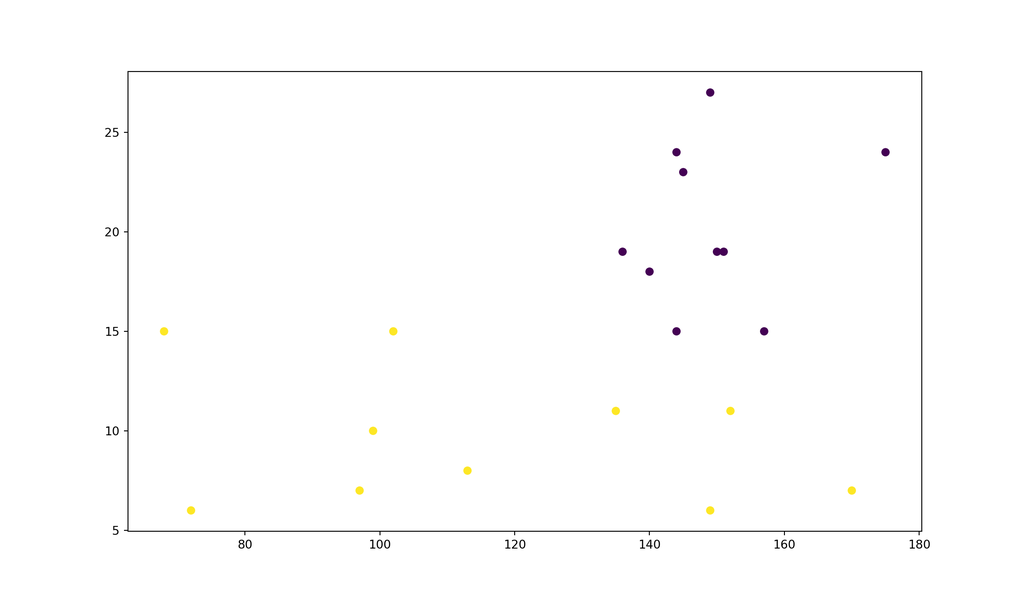

```python
plt.figure(figsize=(12,7))
plt.scatter(x=beer['calories'], y=beer['sodium'], c=kmc.labels_)
plt.show()
```